# QC notebook

Peralta Viteri Christian

2023-01-18

# 1 Introduction

`QC_notebook` is the first of a series of ready-to-do-DataAnalysis. The aim is to turn complex and vast data analysis workflows into user-friendly ready-to-use tools for neuro-scientist.

The framework is based on SingleCellExperiment (SCE) project, where in a single object users can combine different single-cell experiments, i.e. expression or epigenetic data. In addition, several different types of information for both genes or cells. With additional metadata space to store, for instance, literature references.

For more information, visit [SCE](https://www.bioconductor.org/packages/devel/bioc/vignettes/SingleCellExperiment/inst/doc/intro.html).

# 2 Libraries

```r
library(HDF5Array)
library(SingleCellExperiment)
library(cellhashR)
library(DropletUtils)
library(scater)
library(scuttle)
library(scales)
#library(ggExtra)
```

It’s important to set a seed for reproducibility. This is used by algorithms which has a randomized initiation.

```r
set.seed(12)
```

In case you want to check the content of your `.h5` file you can run:

```r
# rna-seq & atac-seq
h5ls("data/muA/raw_feature_bc_matrix.h5")
# hto tags
h5ls("data/muA/muAh/raw_feature_bc_matrix.h5")
```

# 3 Data Loading & SCE object creation

To load the information contained on a h5 file, use `read10xCounts` because it handles automatically the loading of both mRNA data and ATAC data. `read10xCounts` returns a SCE object with all the information. Make sure to split the data so the object contains two separated experiments, one for gene expression and the other for epigenetics, `peaks`.

```r
# Loading data
sce <- read10xCounts("data/muA/filtered_feature_bc_matrix.h5")
# spitting by type, i.e. mRNA & ATAC sequencing
sce <- splitAltExps(sce, rowData(sce)[, "Type"])
# remember to swap experiments to work with the count matrix of your experiment
sce <- swapAltExp(sce, "Gene Expression")

# set row names as unique to avoid redundancy
rownames(sce) <- make.unique(rowData(sce)$Symbol)
# set colnames as the cell barcode
colnames(sce) <- colData(sce)$"Barcode"
```

```r
sce
```

```
## class: SingleCellExperiment
## dim: 32285 20000
## metadata(1): Samples
## assays(1): counts
## rownames(32285): Xkr4 Gm1992 ... AC234645.1 AC149090.1
## rowData names(3): ID Symbol Type
## colnames(20000): AAACAGCCAAACCCTA-1 AAACAGCCAATAGTCT-1 ...
##   TTTGTTGGTTTGGCGG-1 TTTGTTGGTTTGTGGA-1
## colData names(2): Sample Barcode
## reducedDimNames(0):
## mainExpName: Gene Expression
## altExpNames(1): Peaks
```

*To add HTOs as metadata, remember to perform the intersection counts-htos*

The process is repeated, load the data using `read10xCounts` function, set the column names and then perform the intersection.

```r
# using DropletUtils::read10xCounts
htos <- read10xCounts("data/muA/muAh/raw_feature_bc_matrix.h5")
colnames(htos) <- htos$Barcode
htos <- htos[, intersect(colnames(sce), colnames(htos))]
```

```r
# make sure that the colnames are the same in both assays
stopifnot(setequal(colnames(htos), colnames(sce)))
```

Lastly, add the hto data as an alternative experiment.

```r
altExp(sce, "hto") <- SummarizedExperiment(assay(htos))

# hto can be removed

#rm(htos)
```

# 4 Demultiplexing

Now the objective is to demultiplex the data and obtain the HTO tag which was used for each cell.

```r
# make sure to have Python installed with all the required packages if you want to run 'gmm_demux'
reticulate::py_config()
```

```
## python:         /mnt/Data/Bioinfo_platf/wyss_project/docker_envi/py_3_10_venv/bin/python
## libpython:      /usr/lib/python3.10/config-3.10-x86_64-linux-gnu/libpython3.10.so
## pythonhome:     /mnt/Data/Bioinfo_platf/wyss_project/docker_envi/py_3_10_venv:/mnt/Data/Bioinfo_platf/wyss_project/docker_envi/py_3_10_venv
## virtualenv:     /mnt/Data/Bioinfo_platf/wyss_project/docker_envi/py_3_10_venv/bin/activate_this.py
## version:        3.10.6 (main, Nov 14 2022, 16:10:14) [GCC 11.3.0]
## numpy:          /mnt/Data/Bioinfo_platf/wyss_project/docker_envi/py_3_10_venv/lib/python3.10/site-packages/numpy
## numpy_version:  1.23.5
##
## NOTE: Python version was forced by RETICULATE_PYTHON
```

Set a list containing the HTO tags of interest. It will be used to filter out those non interesting tags.

```r
HTO_tag=c("HTO-1","HTO-2","HTO-3","HTO-4","HTO-5","HTO-6","HTO-7","HTO-8","HTO-9","HTO-10")
```

Call `demultiplexer` function and it will take care of all your problems.

```r
sce <- demultiplexer(sce, HTO_tag = HTO_tag)
```

```
## [1] "Converting input data.frame to a matrix"
## [1] "Starting Multiseq deMULTIplex"
```

```
## [1] "no negatives, breaking after iteration: 4"
## [1] "Thresholds:"
## [1] "HTO-1: 0.0915934578062199"
## [1] "HTO-2: 1.10016551985454"
## [1] "HTO-3: 0.411943653147959"
## [1] "HTO-4: 1.55856386517065"
## [1] "HTO-5: 2.64808366737294"
## [1] "HTO-6: 0.714306640136002"
## [1] "HTO-7: 0.22366140053748"
## [1] "HTO-8: 0.849751244899797"
## [1] "HTO-9: 0.185661249545402"
## [1] "HTO-10: 1.00543317383064"
```

```
## [1] "Starting GMM-Demux"
## [1] "==============================GMM-Demux Initialization=============================="
## [2] "Confidence threshold: 0.8"
## [3] "Output directory: /tmp/RtmpYmVSND/file504272e81334"
## [4] "Full classification result is stored in /tmp/RtmpYmVSND/file50426b2e11b6"
## [5] "MSM-free droplets are stored in folder /tmp/RtmpYmVSND/file504272e81334 "
## [6] ""
```

```
## [1] "Starting HTODemux"
## [1] "Will select bottom 2 barcodes as background"
## [1] "Background clusters for HTO-1: 6,1"
## [1] "total cells for background: 7854"
## [1] "Cutoff for HTO-1 : 860 reads"
## [1] "Will select bottom 2 barcodes as background"
## [1] "Background clusters for HTO-2: 6,1"
## [1] "total cells for background: 7854"
## [1] "Cutoff for HTO-2 : 134 reads"
## [1] "Will select bottom 2 barcodes as background"
## [1] "Background clusters for HTO-3: 6,1"
## [1] "total cells for background: 7854"
## [1] "Cutoff for HTO-3 : 503 reads"
## [1] "Will select bottom 2 barcodes as background"
## [1] "Background clusters for HTO-4: 6,1"
```

[output cut: 37 more lines]

```
## [1] "Starting DropletUtils hashedDrops"
## [1] "Inferred Ambience:"
## [1] "HTO-1: 620.787769284225"
## [1] "HTO-2: 108.237100144671"
## [1] "HTO-3: 379.6593977813"
## [1] "HTO-4: 126.376498116653"
## [1] "HTO-5: 17.7224550286182"
## [1] "HTO-6: 107.568608705432"
## [1] "HTO-7: 218.687335588125"
## [1] "HTO-8: 133.869025317133"
## [1] "HTO-9: 176.565911367051"
## [1] "HTO-10: 288.93306010929"
```

```
## [1] "Generating consensus calls"
## [1] "Consensus calls will be generated using: multiseq,gmm_demux,htodemux,dropletutils"
```

```
## [1] "Total cells recovered using majorityConsensusThreshold of 0.3: 3665"
```

```
## [1] "Total concordant: 19427"
## [1] "Total discordant: 573 (2.87%)"
```

# 5 QC metrics computation

Using addPerCellQCMetrics we can add information regarding mitochondrial and ribosomal genes in our assay, really easily. This information is used for checking the quality of the cells in the downstream analysis.

To know more, run ?scuttle::addPerCellQCMetrics

```r
sce <- addPerCellQCMetrics(sce, subset=list(Mito=grep("mt-", rownames(sce),value=TRUE),
                                    Ribo=grep("(^Rpl|^Rps|Mrp)", rownames(sce), value = TRUE)))
```

It’s possible to set the threshold before hand, so it can be passed later to the functions.

```r
mito_max=15
min_nfeatures=log10(200) #be carefull how you set the threshold for number of features. For functions where the scale is log, the threshold is interpreted directly as a logarithm. However, when the scale is not log, you will need to pass a normal value.
```

# 6 QC metrics visualization

An image is worth a thousand words…

For that reason visualizing the QC metrics which were added before are useful to check the quality of our cells.

`plot_QC_Violin()` is the function designed to visualize those QC metrics.

## 6.1 Examples visualizing univariate QC metrics

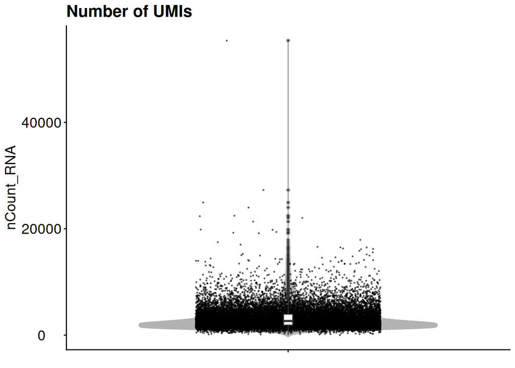

```r
plot_QC_Violin(sce)
```

To know more about what can be plotted:

```r
colnames(colData(sce))
```

```
##  [1] "Sample"                 "Barcode"                "consensus_call"
##  [4] "consensus_call_global"  "sum"                    "detected"
##  [7] "subsets_Mito_sum"       "subsets_Mito_detected"  "subsets_Mito_percent"
## [10] "subsets_Ribo_sum"       "subsets_Ribo_detected"  "subsets_Ribo_percent"
## [13] "altexps_Peaks_sum"      "altexps_Peaks_detected" "altexps_Peaks_percent"
## [16] "total"
```

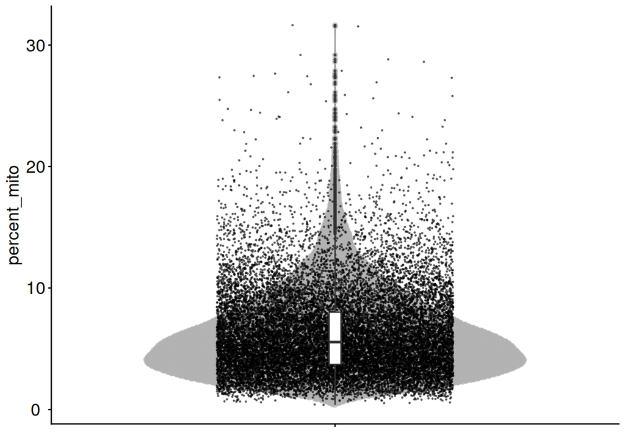

```r
plot_QC_Violin(sce_object = sce, y = "subsets_Mito_percent", ylab = "percent_mito", title = NULL)
```

## 6.2 Relation between nUMIs and nGenes

`plot_UMIvsGene` is meant to facilitate the visualization of log-transformed UMI and detected genes. It will produce a customized scatter pot, for instance axis labels. However, as it returns a ggplot object, one can override these customization.

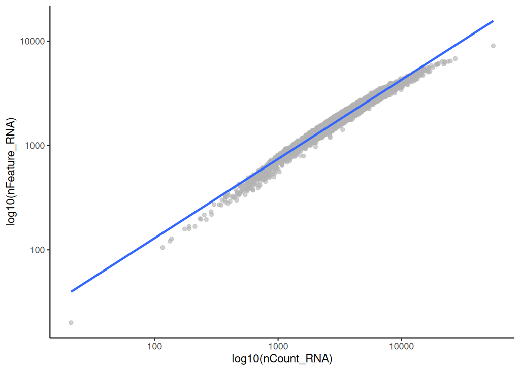

```r
plot_UMIvsGene(sce_object = sce)
```

To plot a scatter pot, with different information, one can call ?scater::plotColData

## 6.3 Plotting a scatter plot of Genes vs percentage mitochondial

In this case it is useful to use the function `plot_QC_scatter` as one can pass thresholds for the metrics visualized. In this case, the function adds a horizontal and/or vertical line marking the threshold(s) specified by the user.

As seen below, when passed two thresholds, the function displays the number of cells that lied at each side of the line.

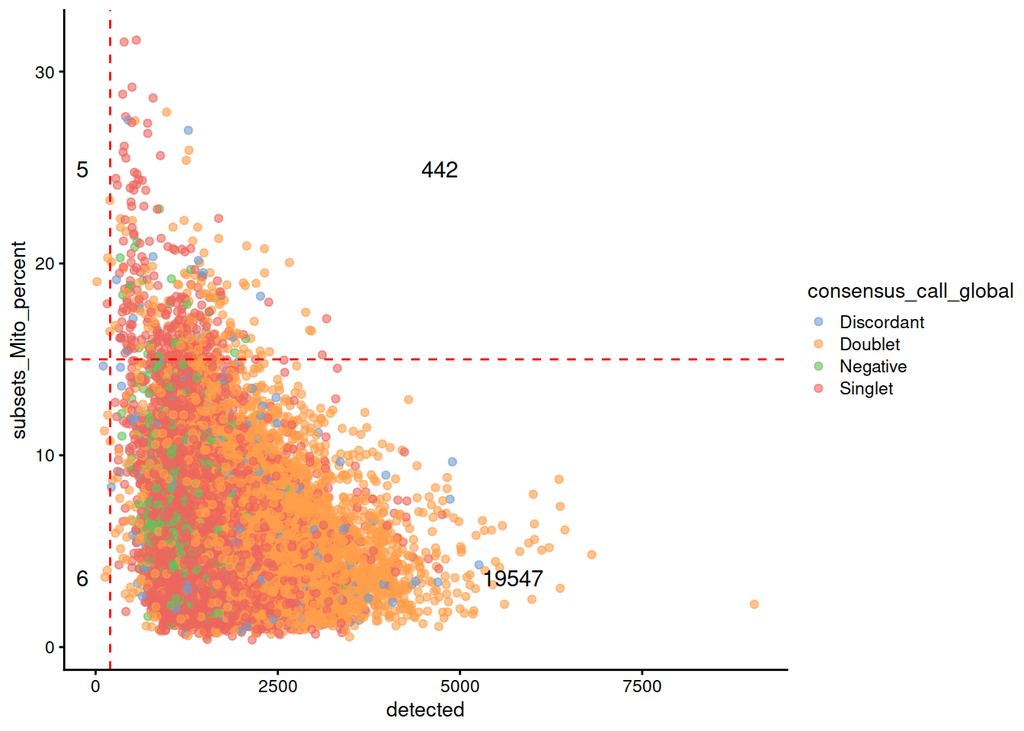

```r
plot_QC_scatter(sce, x="detected", y="subsets_Mito_percent",
            color_by = "consensus_call_global", xthreshold = 200, ythreshold = mito_max)
```

# 7 Set QC status

Here we want to determine what cells has (**in this specific order**):

- More percentage of mitochondrial genes than the threshold
- Lower number of detected genes than the threshold
- Lied below a linear regression shifted by - 0.09

We save this information into a single column, `qc`, which can be used for statistics, plotting and filtering.

`set_QC_status` functions was designed to handle all that operations for you and return the information in the column `qc`. This column can be used for different statistics. It is important to take into account that once a cell fails a criteria, it is excluded from next operations.

```r
sce <- set_QC_status(sce_object = sce, mito_percent_column = "subsets_Mito_percent")
```

We can check the number of cells which failed each condition being:

- fails_maxMito: for maximum percentage for mitochondrial genes.
- fails_minFeat: for minimum number of genes.
- fails_lm: for linear model.

```r
table(sce$qc)
```

```
##
##      fails_lm fails_maxMito fails_minFeat        passed
##            20           447             6         19527
```

Now, the visualizations can be redone, to check the characteristics of the cells when filtering by QC criteria.

Let’s imagine:

*“I wan to see the number of genes for the wells which passed all the quality control”*

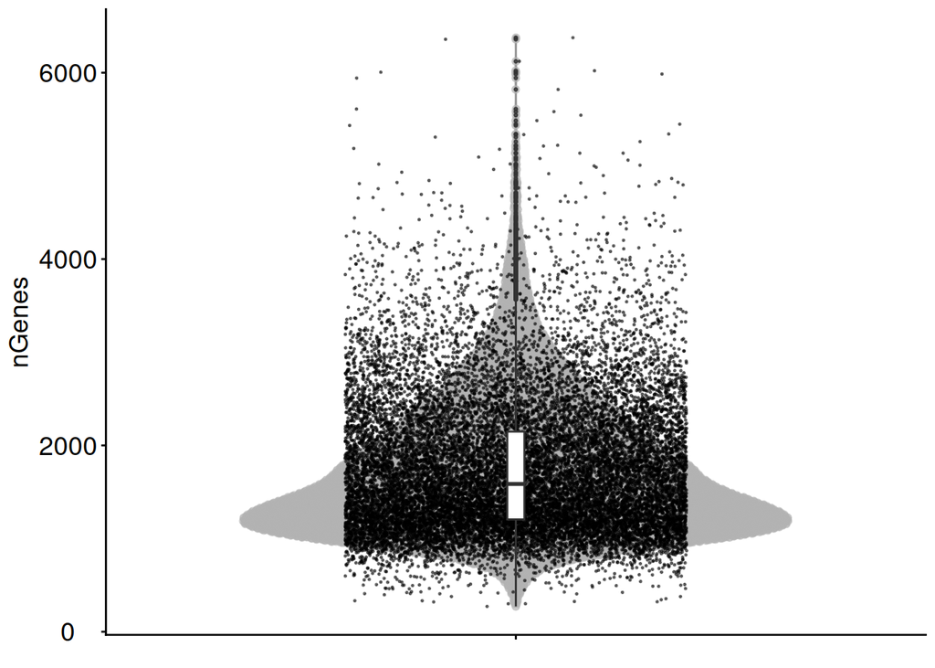

```r
plot_QC_Violin(sce_object = sce[, sce$qc == "passed"],
               y="detected", ylab = "nGenes", title = NULL)
```

One might be interested in having a look at a particular QC metric for a particular condition. It can be easily done by passing that particular condition as `x` parameter to our function `plot_QC_Violin()`.

For more information, run `?scater::plotColData`. Or check this [tutorial](http://bioconductor.org/books/3.16/OSCA.basic/quality-control.html#common-choices-of-qc-metrics)

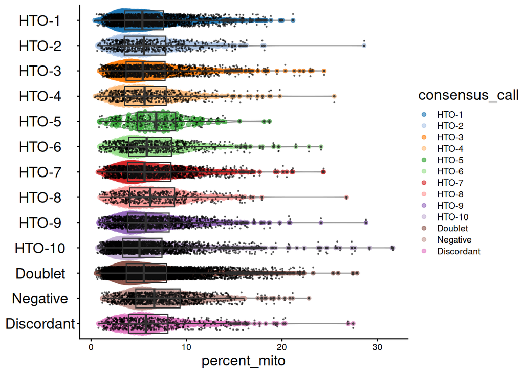

```r
plot_QC_Violin(sce_object = sce, x="consensus_call", y = "subsets_Mito_percent",
               ylab = "percent_mito", title = NULL,
               colour_by="consensus_call") +
  geom_boxplot(alpha=.05) +
  coord_flip() + scale_x_discrete(limits=rev)
```

# 8 Count matrix normalization

Once the QC metrics had been check, and cell had been filtered. It is time to normalize the count matrix.

To do so, one can use simple approach, such as using the log-normalize the matrix. Or, more sophisticated method such as Variance Stabilizing transformation or Analytic Pearson Residual transformation.

In the following sections, it is shown how ot proceed for all this three methods and how to visualized using UMAP representation.

Notice that all normalized counts are included in the same SCE object, allowing to have all-in-one.

## 8.1 Log-normalized counts

For a simple normalization of our count matrix, one can use `logNormCounts()` from the scuttle package.

```r
?scuttle::logNormCounts

# filtering by cell which passed all my QC criteria.
sce <- logNormCounts(sce[, sce$qc == "passed"])
```

```r
assays(sce)
```

[output not shown]

This assay can be used to call dimensionality reduction techniques, such as UMAP.

Since computing UMAP might take several minutes for large datasets, a good idea is to set a BiocParallel object to passed to the BPPARAM parameter in runUMAP. Just modify `workers` parameter according to your machine.

```r
?BiocParallel::MulticoreParam
bp <- BiocParallel::MulticoreParam(workers = 12, RNGseed = 16, progressbar = TRUE)
```

```r
sce <- runUMAP(sce[, sce$qc == "passed"], BPPARAM=bp)
```

And now, simply plot UMAP

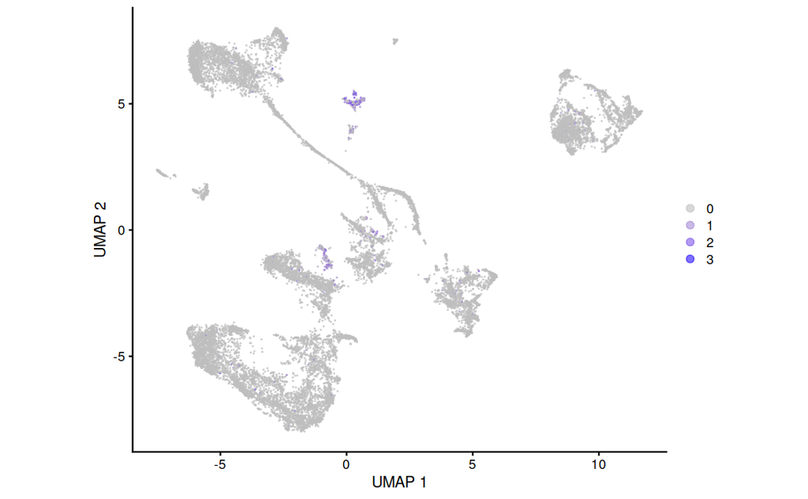

```r
plotUMAP(sce[, sce$qc == "passed"], point_size=.05, colour_by="Sox10") +
  scale_color_gradient(low = "grey", high = "blue") +
  coord_equal() +
  guides(colour=guide_legend(NULL, override.aes = list(size=2)))
```

To know more about what parameters one can tune, run ?scater::plotUMAP

## 8.2 Variance Stabilizing transformation, a.k.a SCTransform()

For information about this technique, visit this [vignette](https://satijalab.org/seurat/articles/sctransform_vignette.html).

```r
sce <- do_vst_transform(sce[, sce$qc=="passed"])
```

```
## Calculating cell attributes from input UMI matrix: log_umi
```

```
## Variance stabilizing transformation of count matrix of size 22226 by 19527
```

```
## Model formula is y ~ log_umi
```

```
## Get Negative Binomial regression parameters per gene
```

```
## Using 2000 genes, 19527 cells
```

```
## Found 124 outliers - those will be ignored in fitting/regularization step
```

```
## Second step: Get residuals using fitted parameters for 22226 genes
```

```
## Computing corrected count matrix for 22226 genes
```

```
## Wall clock passed: Time difference of 2.606592 mins
```

Now we have out count matrix normalized stored as alternative experiment in our SCE object. Remember to swap the experiment and we are go to go for dimensionality reduction.

```r
sce <- swapAltExp(sce, "Gene_Expression_VST")

sce <- runUMAP(sce, BPPARAM=bp, exprs_values="count_vst")
```

We can give also colors to our plots, provided that we explicitly pass the count matrix via the argument `by_exprs_values`. This is essential if our count matrix name is not `logcounts`.

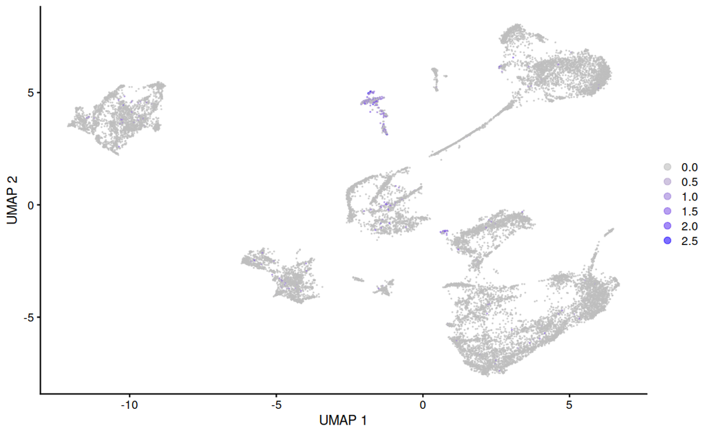

```r
plotUMAP(sce, colour_by="Sox10", point_size=.05, by_exprs_values="count_vst") +
  scale_color_gradient(low = "grey", high = "blue") +
  coord_equal() +
  guides(colour=guide_legend(NULL, override.aes = list(size=2)))
```

## 8.3 Analytic Pearson Residuals Normalization

To know more about this technique, check out the [publication](https://genomebiology.biomedcentral.com/articles/10.1186/s13059-021-02451-7)

```r
sce <- swapAltExp(sce, "Gene Expression")
```

```r
sce <- do_AnPearson_transform(sce[, sce$qc == "passed"])
```

```r
sce <- swapAltExp(sce, "Gene_Expression_PearNorm")
```

```r
sce <- runUMAP(sce, exprs_values="count_AP",
                    name = "UMAP", BPPARAM=bp)
```

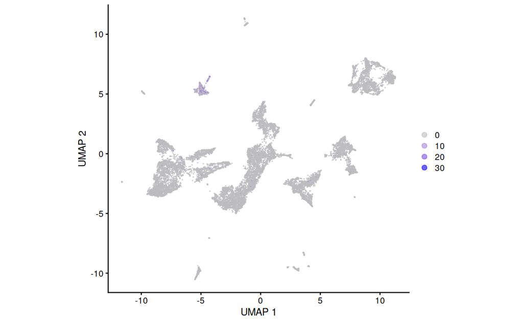

```r
plotUMAP(sce, colour_by="Sox10", point_size=.05, by_exprs_values="count_AP") +
  scale_color_gradient(low = "grey", high = "blue") +
  coord_equal() +
  guides(colour=guide_legend(NULL, override.aes = list(size=2)))
```